# PlottingCode

### Load the `ggplot2` library (for later plotting) and to access the `diamonds` dataset

```r
library(ggplot2)
```

### Quick glance at the data

```r
str(diamonds) # diamonds was loaded automatically when we imported ggplot2
```

```
## tibble [53,940 × 10] (S3: tbl_df/tbl/data.frame)
##  $ carat  : num [1:53940] 0.23 0.21 0.23 0.29 0.31 0.24 0.24 0.26 0.22 0.23 ...
##  $ cut    : Ord.factor w/ 5 levels "Fair"<"Good"<..: 5 4 2 4 2 3 3 3 1 3 ...
##  $ color  : Ord.factor w/ 7 levels "D"<"E"<"F"<"G"<..: 2 2 2 6 7 7 6 5 2 5 ...
##  $ clarity: Ord.factor w/ 8 levels "I1"<"SI2"<"SI1"<..: 2 3 5 4 2 6 7 3 4 5 ...
##  $ depth  : num [1:53940] 61.5 59.8 56.9 62.4 63.3 62.8 62.3 61.9 65.1 59.4 ...
##  $ table  : num [1:53940] 55 61 65 58 58 57 57 55 61 61 ...
##  $ price  : int [1:53940] 326 326 327 334 335 336 336 337 337 338 ...
##  $ x      : num [1:53940] 3.95 3.89 4.05 4.2 4.34 3.94 3.95 4.07 3.87 4 ...
##  $ y      : num [1:53940] 3.98 3.84 4.07 4.23 4.35 3.96 3.98 4.11 3.78 4.05 ...
##  $ z      : num [1:53940] 2.43 2.31 2.31 2.63 2.75 2.48 2.47 2.53 2.49 2.39 ...
```

# Generate a scatterplot in `base R`

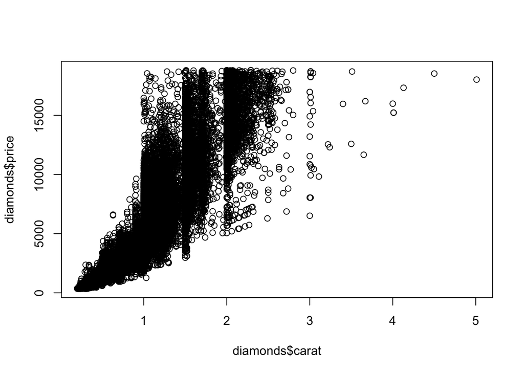

```r
plot(x = diamonds$carat, y = diamonds$price)
```

## Change the shape, color, and size of the points

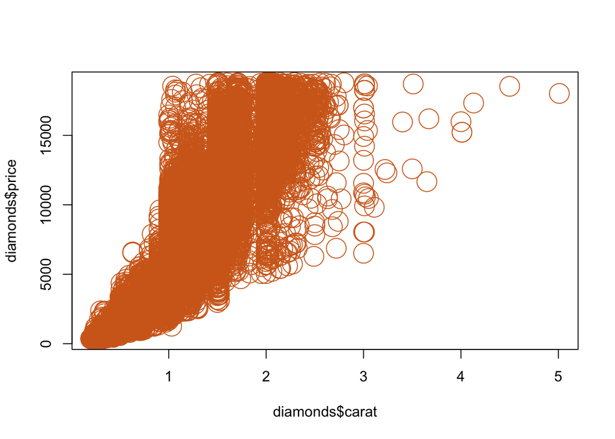

```r
plot(
  x = diamonds$carat,
  y = diamonds$price,
  pch = 21, # shape
  col = 'chocolate', # color
  cex = 3 # size
)
```

## Set the range of the x and y axes, add axis and plot titles and a legend.

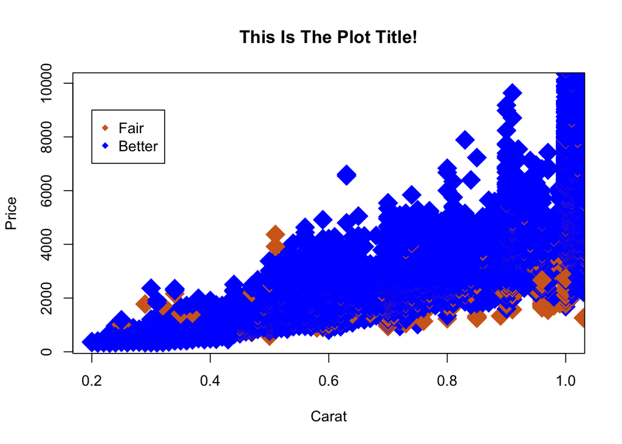

```r
plot(
  x = diamonds$carat,
  y = diamonds$price,
  pch = 18, # shape
  col = ifelse(diamonds$cut == 'Fair', 'chocolate', 'blue'),
  cex = 3, # size
  xlim = c(min(diamonds$carat), 1), # x-axis range
  ylim = c(min(diamonds$price), 10000), # y-axis range
  xlab = 'Carat',
  ylab = 'Price',
  main = 'This Is The Plot Title!' # set the plot title
)
legend(
  x = 0.2, # x-coordinate on the graph of the center of the legend
  y = 9000, # x-coordinate on the graph of the center of the legend
  legend = c('Fair', 'Better'), # the labels for the legend
  col = c('chocolate', 'blue'), # colors in the same order as the above
  pch = 18 # all same shape
)
```

## Adding a regression line To add a regression line, we first fit a model using `lm`, and then supply that model (after generating the scatterplot) to the function `abline`.

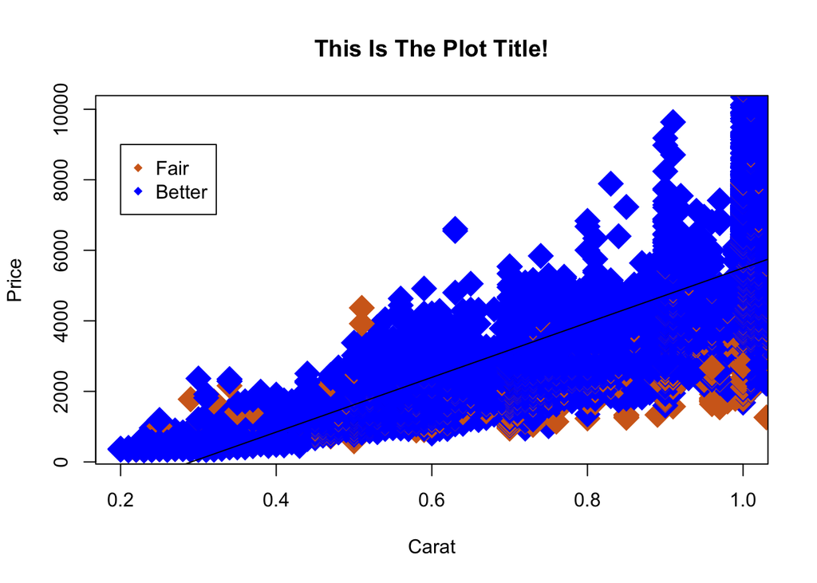

```r
mod <- lm(diamonds$price ~ diamonds$carat)
# Generate the plot again
plot(
  x = diamonds$carat,
  y = diamonds$price,
  pch = 18, # shape
  col = ifelse(diamonds$cut == 'Fair', 'chocolate', 'blue'),
  cex = 3, # size
  xlim = c(min(diamonds$carat), 1), # x-axis range
  ylim = c(min(diamonds$price), 10000), # y-axis range
  xlab = 'Carat',
  ylab = 'Price',
  main = 'This Is The Plot Title!' # set the plot title
)
legend(
  x = 0.2, # x-coordinate on the graph of the center of the legend
  y = 9000, # x-coordinate on the graph of the center of the legend
  legend = c('Fair', 'Better'), # the labels for the legend
  col = c('chocolate', 'blue'), # colors in the same order as the above
  pch = 18 # all same shape
)
# Add the model to the plot:
abline(reg = mod)
```

The regression line can be customized using parameters that govern the aesthetics of lines. These include (but are not limited to):

- `lty`: the type of the line, e.g., solid, dotted, dashed
- `lwd`: width of line  
  `col` is the same as for modifying points.

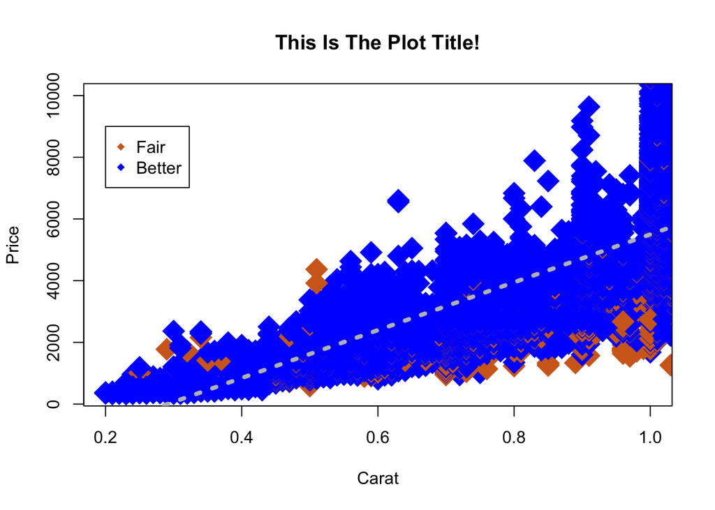

```r
plot(
  x = diamonds$carat,
  y = diamonds$price,
  pch = 18, # shape
  col = ifelse(diamonds$cut == 'Fair', 'chocolate', 'blue'),
  cex = 3, # size
  xlim = c(min(diamonds$carat), 1), # x-axis range
  ylim = c(min(diamonds$price), 10000), # y-axis range
  xlab = 'Carat',
  ylab = 'Price',
  main = 'This Is The Plot Title!' # set the plot title
)
legend(
  x = 0.2, # x-coordinate on the graph of the center of the legend
  y = 9000, # x-coordinate on the graph of the center of the legend
  legend = c('Fair', 'Better'), # the labels for the legend
  col = c('chocolate', 'blue'), # colors in the same order as the above
  pch = 18 # all same shape
)
# Add the model to the plot:
abline(reg = mod, lwd = 4, lty = 3, col ='grey')
```

For a complete overview of all the graphical parameters (such as `col` and `lty`) and what they control on your graph, run:

```r
?`graphical parameters`
```